# Exemplos para processos GARCH multivariados

Kim Samejima Lopes

30 Jan, 2015

Este texto trata da construção de exemplos de modelos GARCH multivariados. Para tanto, considere os modelos a seguir:

- CCC-GARCH e DCC-GARCH
- GO-GARCH

As próximas sessões apresentarão exemplos de tais modelos utilizando as bibliotecas `ccgarch, rmgarch, MTS e gogarch` do **R**.

# 1 CCC-GARCH e DCC-GARCH

## 1.1 CCC-GARCH

Modelos CCC-GARCH são da forma:

1. $\label{eq:cccgarch} \textbf{H}_t = \textbf{D}_t \times \textbf{R} \times \textbf{D}_t \\ \textbf{D}_t= \left[diag\{h_{ii,t}^{1/2}\}\right],i=1,\dots,n$

$h_{ii,t}$ é um modelo GARCH univariado qualquer e $\textbf{R}= \left[\rho_{i,j}\right],i,j=1,\dots,n$ e $\rho_{i,i}=1,i=1,\dots,n$ é uma matriz simétrica, positiva definida.  
Teremos que $\textbf{H}_t$ será positiva definida se e só se todas as n variâncias condicionais forem positivas e $\textbf{H}_t\ge 0$. Em particular um CCC-GARCH(1,1) seria da forma dada em (1), com $h_{ii,t},i=1,\dots,n$ definidos por  
$h_{ii,t}=w_i+a_i\epsilon^2_{i,t-1}+b_i h_{ii,t-1},i=1\dots,n$  
Ou seja, cada $h_{ii,t}$ é dado por um GARCH(1,1).

### 1.1.1 Exemplo Simulado

Utilizando o pacote `ccgarch`, simularemos um modelo CCC-GARCH(1,1) bivariado definido por: $\textbf{R}=\left(\begin{array}{cc} 1 & 0.3 \\ 0.3 & 1\end{array}\right) \\ h_{11,t}= 0.05 + 0.1 \epsilon^2_{1,t-1}+ 0.6 h_{11,t-1} \\ h_{22,t}= 0.02 + 0.05 \epsilon^2_{2,t-1}+ 0.75 h_{22,t-1}$

```
### EXEMPLOS USANDO O PACOTE 'ccgarch'
# eccc.sim Arguments:

# 'nobs'  a number of observations to be simulated (T)
# 'a'     a vector of constants in the GARCH equation (N×1)
# 'A'     an ARCH parameter matrix in the GARCH equation.
#         Can be a diagonal matrix for the original CCC-GARCH model or a full
#         matrix for the extended model (N×N)
# 'B'     a GARCH parameter matrix in the GARCH equation.
#         Can be a diagonal matrix for the original CCC-GARCH model or a full
#         matrix for the extended model (N×N)
# 'R'     a constant conditional correlation matrix (N×N)
# 'd.f'   the degrees of freedom parameter for the t-distribution
# 'model' "diagonal" for the diagonal model and "extended" for the extended model

c.a1=c(0.05,0.02)
c.A1=matrix(c(0.1,0,0,0.05),ncol=2)
c.B1=matrix(c(0.6,0,0,0.75),ncol=2)
c.R1=matrix(c(1,0.3,0.3,1),ncol=2)
c.H1<-eccc.sim(nobs=1000, c.a1, c.A1, c.B1, c.R1, d.f=5, model="diagonal")

#'h'      a matrix of the simulated conditional variances (T × N )
#'eps'    a matrix of the simulated time series with (E)CCC-GARCH process (T × N )
```

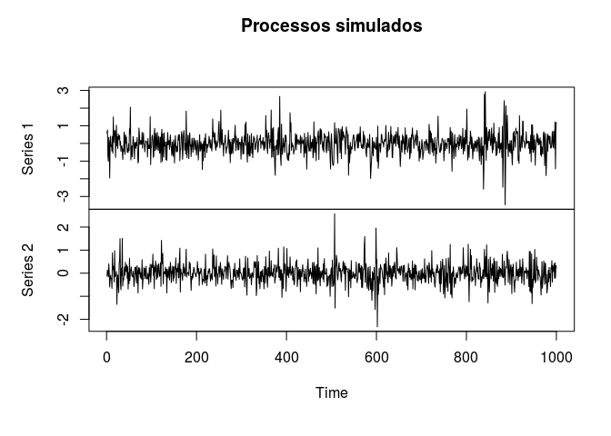

```r
plot.ts(c.H1$eps, main = "Processos simulados")
```

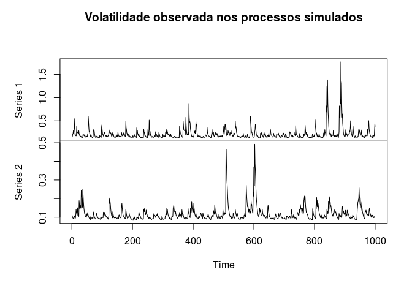

```r
plot.ts(c.H1$h, main="Volatilidade observada nos processos simulados")
```

Para o processo simulado, vamos estimar os parâmetros utilizando o mesmo pacote, com a função `eccc.estimation`. Temos duas séries simuladas, e suporemos então que elas seguem um CCC-GARCH(1,1) e são regidas pelo processo:

2. $\textbf{h}_t=\left( \begin{array}{c} h_{11,t} \\ h_{22,t} \end{array} \right)=\textbf{w}+\textbf{A}\textbf{$\epsilon$}_{t-1}\textbf{$\epsilon$}_{t-1}^T+\textbf{B}\textbf{h}_{t-1}=\\ = \left(\begin{array}{c} a_{1} \\ a_{2} \end{array} \right) + \left(\begin{array}{cc} A_{11} & 0 \\ 0 & A_{22} \end{array} \right) \left(\begin{array}{c} \epsilon^2_{1,t-1} \\ \epsilon^2_{2,t-1} \end{array} \right) + \left(\begin{array}{cc} B_{11} & 0 \\ 0 & B_{22} \end{array} \right) \left(\begin{array}{c} h_{11,t-1} \\ h_{22,t-1} \end{array} \right)$

Para estimar o processo, é necessário sugerir os ‘chutes’ iniciais para o algoritmo de otimização. Façamos então:

$\textbf{w}_0=\textbf{1}_2 \\ \textbf{A}_0=\textbf{I}_2 \\ \textbf{B}_0=\textbf{I}_2 \\ \textbf{R}_0=\textbf{I}_2 \\$

```r
c.w0=c(1,1)
c.A0=diag(2)
c.B0=diag(2)
c.R0=diag(2)
c.fit1<-eccc.estimation(a=c.w0,A=c.A0,B=c.B0,R=c.R0,model="diagonal",dvar=c.H1$eps)
c.fit1$opt$convergence
```

```
## [1] 0
```

```r
# $convergence == 0 ## Means convergence criteria has reached
```

Os resultados da estimação foram:

```r
c.fit1$para.mat
```

```
## $a
## [1] 0.098422 0.030121
##
## $A
##         [,1]    [,2]
## [1,] 0.15865 0.00000
## [2,] 0.00000 0.12523
##
## $B
##         [,1]    [,2]
## [1,] 0.56705 0.00000
## [2,] 0.00000 0.71541
##
## $R
##         [,1]    [,2]
## [1,] 1.00000 0.34062
## [2,] 0.34062 1.00000
```

```r
c.fit1$out
```

```
##                       a1       a2      A11       A22       B11      B22
## para.estimates 0.0984224 0.030121 0.158648 0.1252254 0.5670549 0.715409
## Inv. Hessian   0.0092265 0.028668 0.026686 0.0081792 0.0046248 0.047223
## Outer Prod.    0.0233127 0.031010 0.080782 0.0075643 0.0253676 0.056035
## Robust         0.0093408 0.035599 0.028977 0.0111236 0.0033475 0.065910
##                     R21
## para.estimates 0.340622
## Inv. Hessian   0.027924
## Outer Prod.    0.027862
## Robust         0.028438
```

## 1.2 DCC-GARCH

Modelos DCC-GARCH são uma generalização do caso CCC-GARCH, isto é, temos a matris **R** não necessariamente fixa, ou seja, ela varia no tempo:

3. $\label{eq:dccgarch} \textbf{H}_t = \textbf{D}_t \times \textbf{R}_t \times \textbf{D}_t \\$

$\textbf{D}_t$ é definida como em (1) e $\textbf{R}_t$ tem expressão específica. Tse e Tsui(2002) sugerem $\textbf{R}_t$ definida por (DCCt-GARCH)

4. $\textbf{R}_t=(1-\theta_1-\theta_2)\textbf{R}+\theta_1\Psi_{t-1}+\theta_2\textbf{R}_{t-1}$

Em que $\textbf{R}= \left[\rho_{i,j}\right], i,j = 1,\dots,n$ e $\rho_{i,i}=1,i=1,\dots,n$ é uma matriz simétrica, positiva definida e $\Psi_{t-1}$ uma matriz de correlações de $\epsilon_\tau$ definida convenientemente.  
Já Engle(2002) propõe $\textbf{R}_t$ como (DCCe-GARCH):

5. $\textbf{R}_t=\left[diag\{\textbf{Q}_t\}\right]^{1/2}\times \textbf{Q}_t \times \left[diag\{\textbf{Q}_t\}\right]^{1/2}$

Com $\textbf{Q}_t$ não negativa definida, de ordem $n\times n$ definida de forma semelhante a $\textbf{R}_t$ em (4), isto é:

$\textbf{Q}_t=(1-\alpha-\beta)\textbf{Q}+\alpha \textbf{u}_{t-1}\textbf{u}^T_{t-1}+\beta\textbf{Q}_{t-1}$

### 1.2.1 Exemplo Simulado (DCCe-GARCH)

Para simular o processo DCC-GARCH, consideraremos os pacotes `ccgarch`. Compararemos o resultado da estimação através dos pacotes `ccgarch`, `rmgarch` e `MTS`, para que possamos comparar suas performances. A parametrização utilizada será aquela proposta por Engle ( veja equação 5).

```
### EXEMPLOS USANDO O PACOTE 'ccgarch'
# dcc.sim Arguments:

# 'nobs'     a number of observations to be simulated (T )
# 'a'        a vector of constants in the vector GARCH equation (N × 1)
# 'A'        an ARCH parameter matrix in the vector GARCH equation (N × N )
# 'B'        a GARCH parameter matrix in the vector GARCH equation (N × N )
# 'R'        an unconditional correlation matrix (N × N )
# 'dcc.para' a vector of the DCC parameters (2 × 1)
# 'd.f'      the degrees of freedom parameter for the t-distribution
# 'model'    a character string describing the model.
#            "diagonal" for the diagonal model  and "extended" for the extended
#            (full ARCH and GARCH parameter matrices) model

d.a1=c(0.05,0.02)
d.A1=matrix(c(0.1,0,0,0.05),ncol=2)
d.B1=matrix(c(0.6,0,0,0.75),ncol=2)
d.R1=matrix(c(1,0.3,0.3,1),ncol=2)
d.alpha1 = 0.1
d.beta1  = 0.2
d.H1<-dcc.sim(nobs=1000, d.a1, d.A1, d.B1, d.R1, dcc.para=c(d.alpha1,d.beta1), d.f=5, model="diagonal")

# 'dcc'      a matrix of the simulated dynamic conditional correlations (T × N 2 )
# 'h'        a matrix of the simulated conditional variances (T × N )
# 'eps'      a matrix of the simulated time series with DCC-GARCH process (T × N )
```

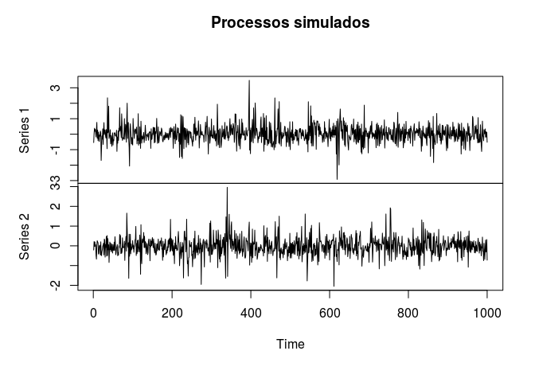

```r
plot.ts(d.H1$eps, main = "Processos simulados")
```

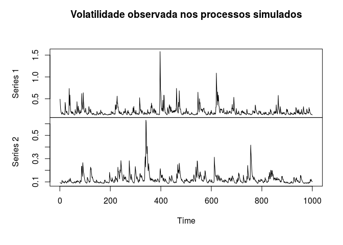

```r
plot.ts(d.H1$h, main="Volatilidade observada nos processos simulados")
```

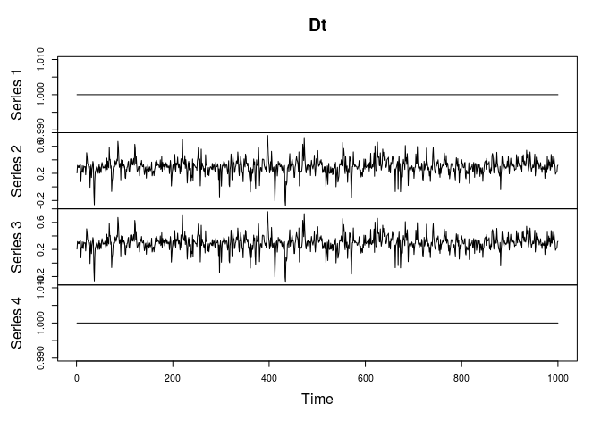

```r
plot.ts(d.H1$dcc, main="Dt")
```

### 1.2.2 Estimação via `ccgarch`

Para estimar os parâmetros do processo simulado acima, considere a função `dcc.est` do `ccgarch`, que estima os parâmetros via máxima verossimilhança em dois estágios. Assim como no caso do CCC-GARCH, utilizaremos as seguintes quantidades iniciais para o processo iterativo:

```r
d.w0=c(0.2,0.2)
d.A0=diag(2)
d.B0=diag(2)
d.alpha0 = 0.5
d.beta0  = 0.5
d.fit1<-dcc.estimation(inia=d.w0,iniA=d.A0,iniB=d.B0,ini.dcc=d.w0,model="diagonal",dvar=d.H1$eps)
```

```
## *  Estimation has been completed.                              *
## *  The outputs are saved in a list with components:            *
## *    out    : the estimates and their standard errors          *
## *    loglik : the value of the log-likelihood at the estimates *
## *    h      : a matrix of estimated conditional variances      *
## *    DCC    : a matrix of DCC estimates                        *
## *    std.resid : a matrix of the standardised residuals        *
## *    first  : the results of the first stage estimation        *
## *    second : the results of the second stage estimation       *
```

Os resultados da estimação seguem abaixo:

```r
d.fit1$out
```

```
##                 a1       a2     A11      A22      B11     B22 dcc alpha
## estimates 0.056713 0.035230 0.16272 0.103749 0.669107 0.74201  0.124399
## std.err   0.026292 0.067298 0.12208 0.016182 0.035568 0.08875  0.031886
##           dcc beta
## estimates  0.49716
## std.err    0.13897
```

### 1.2.3 Estimação via `rmgarch`

```r
spec1 = ugarchspec(distribution = "std")
mspec = multispec(c(spec1,spec1))
fitspec=dccspec(mspec,VAR=TRUE,lag=1,dccOrder=c(1,1),model="DCC",distribution="mvt")

d.fit2=dccfit(fitspec,d.H1$eps)
```

O resultado do modelo ajustado é o que se segue:

```r
d.fit2
```

```
##
## *---------------------------------*
## *          DCC GARCH Fit          *
## *---------------------------------*
##
## Distribution         :  mvt
## Model                :  DCC(1,1)
## No. Parameters       :  18
## [VAR GARCH DCC UncQ] : [6+8+3+1]
## No. Series           :  2
## No. Obs.             :  1000
## Log-Likelihood       :  -1339.9
## Av.Log-Likelihood    :  -1.34
##
## Optimal Parameters
## -----------------------------------
##                   Estimate  Std. Error  t value Pr(>|t|)
## [Asset_1].omega   0.041418    0.018183   2.2778 0.022736
## [Asset_1].alpha1  0.130840    0.048307   2.7085 0.006758
## [Asset_1].beta1   0.749744    0.085887   8.7294 0.000000
## [Asset_1].shape   5.113694    0.656430   7.7902 0.000000
## [Asset_2].omega   0.039443    0.025445   1.5501 0.121112
## [Asset_2].alpha1  0.101259    0.043286   2.3393 0.019320
## [Asset_2].beta1   0.725627    0.144719   5.0140 0.000001
## [Asset_2].shape   5.131063    0.675014   7.6014 0.000000
## [Joint]dcca1      0.136224    0.030728   4.4332 0.000009
## [Joint]dccb1      0.441155    0.088872   4.9640 0.000001
## [Joint]mshape     5.629982    0.451008  12.4831 0.000000
##
## Information Criteria
## ---------------------
##
## Akaike       2.7158
## Bayes        2.8041
## Shibata      2.7151
## Hannan-Quinn 2.7493
##
##
## Elapsed time : 3.0495
```

### 1.2.4 Estimação via `MTS`

O ajuste do modelo DCC-GARCH via pacote `MTS` é apresentado por Tsay(2014) e é realizado em duas etapas. Em primeiro lugar, ajusta-se um modelo GARCH é ajustado para as componentes da série multivariada e depois os paretros do modelo DCC-GARCH são estimados. Inicialmente, apenas o modelo DCC(1,1) está implementado. A sintaxe para o ajuste do processo simulado é:

```r
mtspre.fit3=dccPre(d.H1$eps, include.mean = T, p = 0, cond.dist = "std")
```

```
## Sample mean of the returns:  0.023047 -0.019557
## Component:  1
## Estimates:  0.042374 0.13458 0.74396 5.0975
## se.coef  :  0.016382 0.041482 0.07412 0.81529
## t-value  :  2.5866 3.2443 10.037 6.2525
## Component:  2
## Estimates:  0.039859 0.10117 0.72462 5.017
## se.coef  :  0.020426 0.038966 0.11472 0.77394
## t-value  :  1.9514 2.5963 6.3162 6.4824
```

```r
d.fit3=dccFit(mtspre.fit3$sresi, type = "Engle", theta = c(d.alpha0, d.beta0),
       ub = c(0.92, 0.92), lb = c( 1e-04, 1e-04), cond.dist = "std", df = 5)
```

```
## Estimates:  0.44234 0.14215 5.5709
## st.errors:  0.13729 0.038773 0.50538
## t-values:   3.2219 3.6663 11.023
```

Os resultados para o ajuste do modelo simulado são apresentados a seguir:

```r
names(d.fit3$estimates)<-c("theta1","theta2","df.t")
mtspre.fit3$est
```

```
##         omega  alpha1   beta1  shape
## [1,] 0.042374 0.13458 0.74396 5.0975
## [2,] 0.039859 0.10117 0.72461 5.0170
```

```r
d.fit3$estimates
```

```
##  theta1  theta2    df.t
## 0.44234 0.14215 5.57088
```

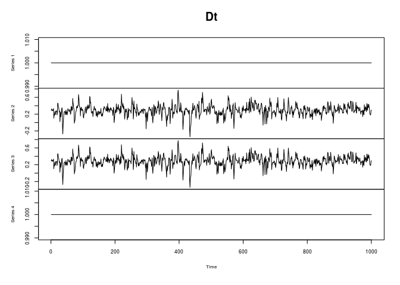

```r
plot.ts(d.fit3$rho.t,cex.lab=0.5,cex.axis=0.8, main = "Dt")
```

## 1.3 Conclusões a cerca dos modelos CCC-GARCH e DCC-GARCH

Vimos tanto no exemplo do CCC-GARCH quanto no do DCC-GARCH que o pacote `ccgarch` não apresentou estimativas satisfatórias para os parâmetros dos modelos simulados, principalmente nos casos dos parâmetros do vetor **a** e da matriz **A** da equação (2) que define as componentes dos processos GARCH.  
Da mesma forma, os pacotes `rmgarch` e `MTS` não apresentaram resultados próximos dos verdadeiros valores dos parâmetros. Dentre os três ajustes, o ajuste do pacote `MTS` foi o que apresentou menos discrepância, tendo maior viés na estimativa dos parâmetros do modelo DCC(1,1) do que nos modelos GARCH de sua primeira etapa.

# 2 GO-GARCH

Nos modelos GO-GARCH, estamos interessados em construir decomposições ortogonais para a matriz de covariâncias $\Sigma_t$. Em outras palavras, buscamos a seguinte igualdade:

$Cov(r_t | \mathbb{F}_{t-1}) = \Sigma_t = M V_t M^T$

em que $V_t$ é a matriz de covariâncias das componentes latentes do processo, $\textbf{b}_t=(b_{1t},b_{2t},\dots,b_{kt}),k \ge n$, i.e., $V_t=Cov(\textbf{b}_t | \mathbb{F}_{t-1})$. Se a transformação acima existir, então as variáveis latentes podem ser expressas por:

6. $\textbf{b}_t = M^{-1} r_t$

Assumiremos que $V_t$ é diagonal e que a variância não-condicional de $\textbf{b}_t$ é a matriz identidade $\textbf{I}_k$. Ainda, assumiremos que a matriz **M** é invariante no tempo.

## 2.1 Simulação

Considere um processo composto por variáveis latentes $b_{i,t},i=1,2,3$. Suporemos que estas variáveis são fatores independentes e seguem um GARCH(1,1) de parâmetros $\alpha=0.2$ e- $\beta=0.7$, cada uma delas. Utilizamos o pacote `fGarch` para simular cada uma destas variáveis:

```
gog.spec = garchSpec(model = list(alpha = 0.2, beta = 0.7))
gog.b1<-garchSim(gog.spec, n = 1000)
gog.b2<-garchSim(gog.spec, n = 1000)
gog.b3<-garchSim(gog.spec, n = 1000)
gog.bt<-cbind(gog.b1,gog.b2,gog.b3)
```

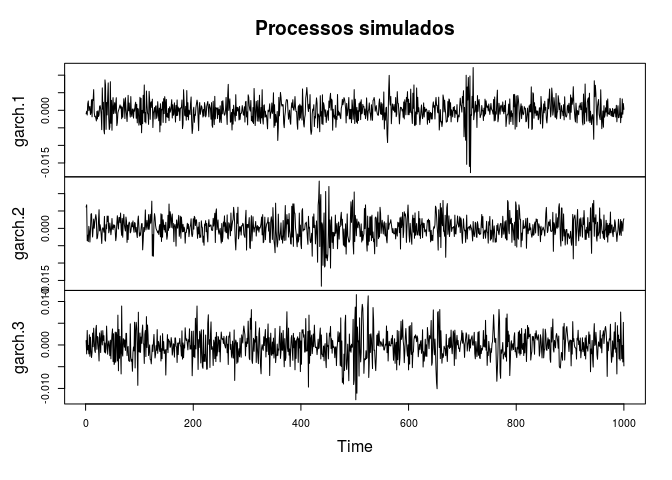

```r
plot.ts(as.ts(gog.bt), main="Processos simulados")
```

A Matriz M apresentada em (6) é dada por:

$M= \left( \begin{array}{ccc} -0.4 & 0.1 & -0.3\\ 0.3 & 0.3 & -0.1\\ 0.4 & -0.1 & -0.5 \end{array} \right)$

```
M=matrix(c(-0.4,0.1,-0.3,0.3,0.3,-0.1,0.4,-0.1,-0.5),ncol=3,byrow=T)
```

Assim, a partir da equação (6) teremos:

```
gog.rt<-t(M%*%t(bt))
```

## 2.2 Estimação via `gogarch`

Estimaremos os parâmetros do processo simulado no início da seção a partir do pacote `gogarch` do **R**. Os valores ajustados para os processos GARCH dos fatores encontram-se próximos aos valores reais utilizados na simulação do processo. A matriz Z estimada, de acordo com Van Der Weide (2002), deveria representar os valores da matriz **M** em (6) e a matriz U, a matriz rotacionada ortogonal.

```r
system.time(fit1_gogarch<-gogarch(gog.rt*10^3,~garch(1,1),estby="ml"))
```

```
##    user  system elapsed
##  17.471   0.000  17.498
```

```r
# Slots:
#   opt: Object of class "list": List returned by nlminb.
#   estby: Object of class "character": Estimation method.
#   models: Object of class "list": List of univariate GARCH model fits.
#   garchf: Object of class "formula": Garch formula used for uncorrelated component GARCH models.
#   name: Object of class "character": The name of the original data object.
#   X: Object of class "matrix": The data matrix.
#   V: Object of class "matrix": Covariance matrix of X.
#   Z: Object of class "matrix": Transformation matrix.
#   H: Object of class "list": List of conditional variance/covariance matrices.

#   U: Object of class "matrix": Orthogonal matrix.
#   Y: Object of class "matrix": Extra  cted component matrix.

#   P: Object of class "matrix": Left singular values of Var/Cov matrix of X.
#   Dsqr: Object of class "matrix": Square roots of eigenvalues on diagonal, else zero.

fit1_gogarch
```

```
##
## ****************
## *** GO-GARCH ***
## ****************
##
## Components estimated by: maximum likelihood
## Dimension of data matrix: (1000 x 3).
## Formula for component GARCH models: ~ garch(1, 1)
##
## Orthogonal Matrix U:
##            [,1]     [,2]     [,3]
## [1,] 1.0478e-17 -0.67246  0.74014
## [2,] 1.7112e-01 -0.72922 -0.66254
## [3,] 9.8525e-01  0.12665  0.11507
##
## Linear Map Z:
##          [,1]    [,2]     [,3]
## [1,]  0.69552 1.09863 -1.00335
## [2,] -0.85554 0.70368  0.96697
## [3,]  0.75676 0.55470  1.88181
##
## Estimated GARCH coefficients:
##       omega  alpha1   beta1
## y1 0.044246 0.22426 0.68510
## y2 0.196219 0.20642 0.71274
## y3 0.062684 0.20047 0.72584
##
## Convergence codes of component GARCH models:
## y1 y2 y3
##  1  1  1
```

## 2.3 Estimação via `rmgarch`

Também é possível ajustar modelos GO-GARCH a partir do pacote `rmgarch`. Para tanto, especifiquemos os parâmetros do processo inicialmente:

```r
gogarchspec2<-gogarchspec(mean.model=list(model="constant"),distribution.model="mvnorm")
```

O ajuste do modelo via `rmgarch` se da a partir da função `gogarchfit`. Inicialmente o pacote sugere a mudança de escala na matriz de dados, já que os valores originais próximos a zero (usual para log-retornos) apresentou muitos problemas de matrizes não invertíveis. Logo, ajustemos o modelo para a série de interesse re-escalada para $r_t \times 1000$.

```r
gogarchfit2<-gogarchfit(gogarchspec2,gog.rt*10^3)
gogarchfit2
```

```
##
## *------------------------------*
## *        GO-GARCH Fit          *
## *------------------------------*
##
## Mean Model       : CONSTANT
## GARCH Model      : sGARCH
## Distribution : mvnorm
## ICA Method       : fastica
## No. Factors      : 3
## No. Periods      : 1000
## Log-Likelihood   : -5331.14
## ------------------------------------
##
## U (rotation matrix) :
##
##         [,1]    [,2]    [,3]
## [1,]  0.4029 0.00497 -0.9152
## [2,] -0.9098 0.11114 -0.3999
## [3,]  0.0997 0.99379  0.0493
##
## A (mixing matrix) :
##
##        [,1]   [,2]  [,3]
## [1,] -0.979 -0.168 -1.30
## [2,] -0.362 -1.008  1.01
## [3,] -1.357  0.472  1.54
```

```r
coef(gogarchfit2)
```

```
##             F_1      F_2      F_3
## omega  0.076444 0.083501 0.074528
## alpha1 0.196727 0.220069 0.230009
## beta1  0.728634 0.690152 0.696782
```

O pacote constrói ainda as superfícies estimadas de relação entre as diferentes séries da matriz de dados, a partir dos fatores estimados:

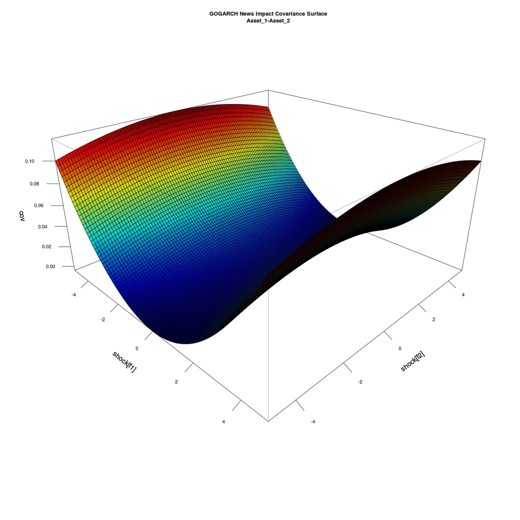

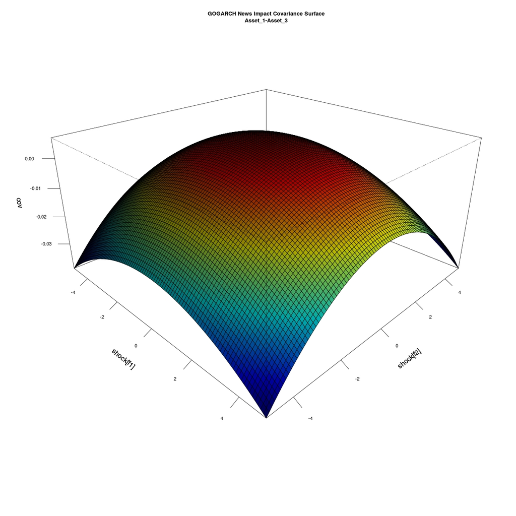

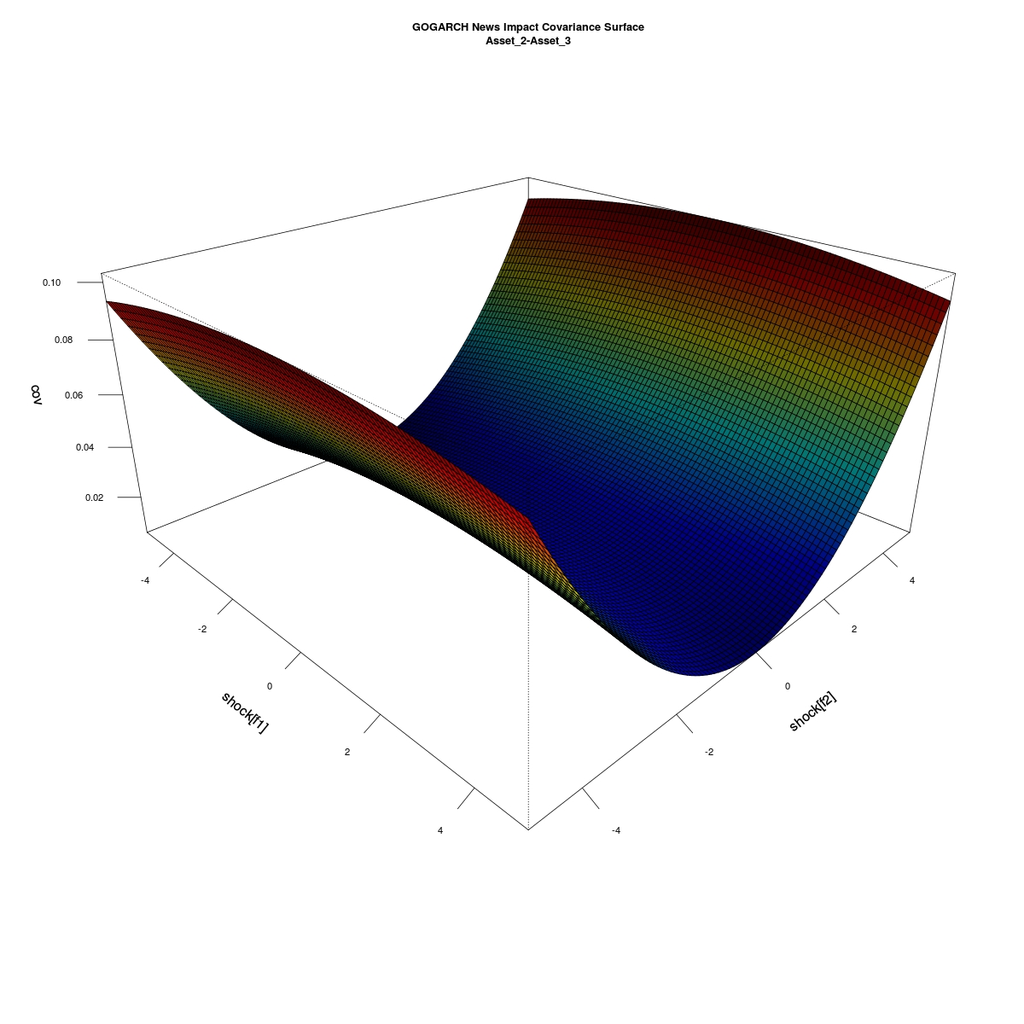

## 2.4 Referências

- Engle, R.F. and Granger, C.W.J. , *Co-integration and Error Correction: Representation, Estimation, and Testing*, Econometrica, 55(2), pp. 251-76, 1987.
- Hannan, E.J. and Quinn, B.G. , *The Determination of the Order of an Autoregression*, Journal of the Royal Statistical Society. Series B (Methodological) 41(2):190–195, Wiley, 1979.
- Johansen, S., *Statistical Analysis of cointegration vectors*, Journal of Economic Dynamics and Control, 12, 231-254, 1988.
- Laurent S., *Analytical Derivates of the APARCH Model*, Computational Economics, 24(1), pp 51-57, August 2004, Kluwer Academic Publishers.
- Morettin P.A., *Econometria Financeira*, Blucher 2ed. Sao Paulo, 2013.
- Morettin P.A. e Toloi, C.M.C, *Análise de Séries Temporais*, Blucher, Sao Paulo, 2006.
- Phillips, P.C.B. and Ouliaris, S., *Asymptotic Properties of Residual Based Tests for Cointegration*, Econometrica, 58(1), 165–193, 1990.
- Shumway R.H. and Stoffer D.S., *Time Series Analysis and Its Applications: With R Examples*, 3rd ed. Springer Texts in Statistics, 2011.
- Taylor, J.W., *A Quantile Regression Neural Network Approach to Estimating the Conditional Density of Multiperiod Returns*, Journal of Forecasting, 19:299–311, Wiley and Sons, 2000.
- Tsay, R.S., *Analysis of Financial Time Series*, 2nd ed., Wiley, 2005.
- Tsay, R.S., *Multivariate Analysis of Time Series with R and Financial Applications*, Wiley and Sons, 2014.
- Zivot, E., Wang, J., *Modeling Financial Time Series with S-PLUS*, 2nd ed., Springer, 2006.
- Van Der Weide, R., *GO-GARCH: A Multivariate Generalized Orthogonal GARCH Model* Journal of Applied Econometrics, 17:549–564, 2002.